# Задача

# Service Level 85%

```r
x_test_85 <- c(rep(0, 61764), rep(1, 350000))
mean(x_test_85)
```

```
## [1] 0.8500015
```

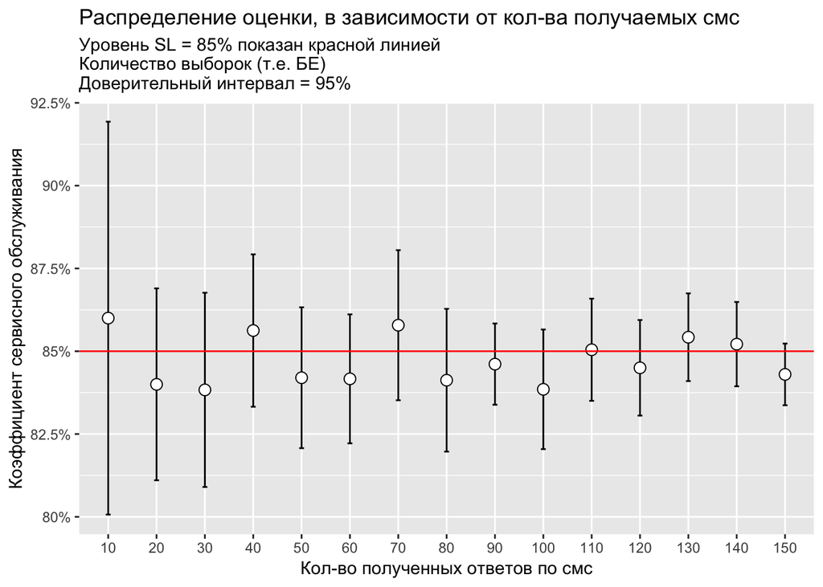

```r
k_85 <- feedback(x_test_85, seq(10, 150, 10), 1:20)

ggplot(k_85, aes(factor(sms), mean)) +
  geom_errorbar(aes(ymin = ymin, ymax = ymax), width = 0.1, lwd = 0.5) +
  geom_point(shape = 21, size = 3, fill = 'white') +
  geom_hline(yintercept = 0.85, color ="red") +
  labs(x = "Кол-во полученных ответов по смс",
       y = "Коэффициент сервисного обслуживания",
       title ="Распределение оценки, в зависимости от кол-ва получаемых смс",
       subtitle = "Уровень SL = 85% показан красной линией \nКоличество выборок (т.е. БЕ) \nДоверительный интервал = 95%") +
  scale_y_continuous(labels = function(x) paste0(x*100, "%"))
```

# Service Level 90%

```r
x_test_90 <- c(rep(0, 6666), rep(1, 60000))
mean(x_test_90)
```

```
## [1] 0.900009
```

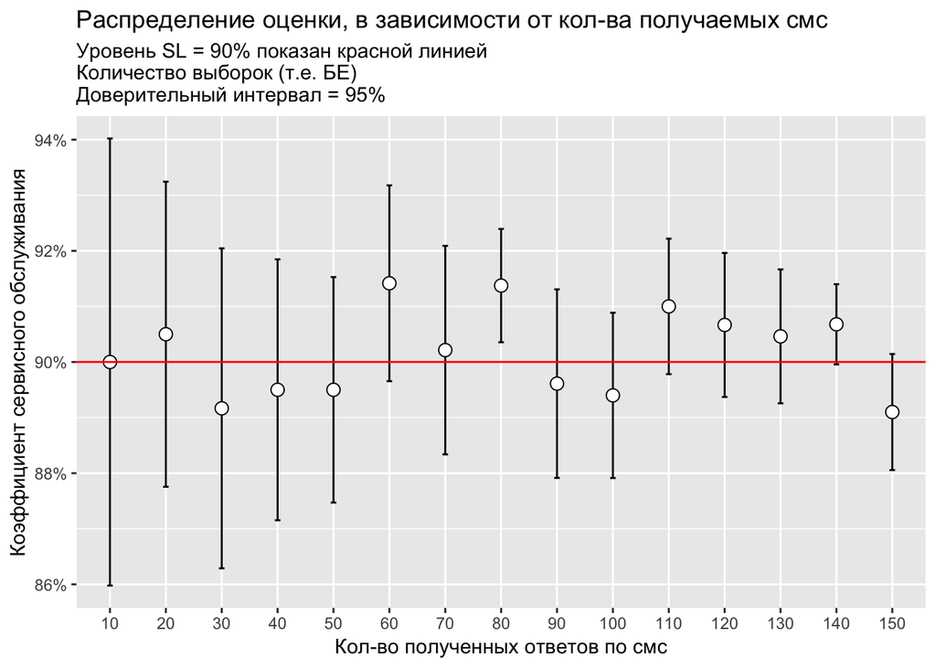

```r
k_90 <- feedback(x_test_90, seq(10, 150, 10), 1:20)

ggplot(k_90, aes(factor(sms), mean)) +
  geom_errorbar(aes(ymin = ymin, ymax = ymax), width = 0.1, lwd = 0.5) +
  geom_point(shape = 21, size = 3, fill = 'white') +
  geom_hline(yintercept = 0.900009, color ="red") +
  labs(x = "Кол-во полученных ответов по смс",
       y = "Коэффициент сервисного обслуживания",
       title ="Распределение оценки, в зависимости от кол-ва получаемых смс",
       subtitle = "Уровень SL = 90% показан красной линией \nКоличество выборок (т.е. БЕ) \nДоверительный интервал = 95%") +
  scale_y_continuous(labels = function(x) paste0(x*100, "%"))
```

# Выводы

Во всех полученных выборках (70, 80, 85, 90) при увеличении количества оценок закономерно улучшается точность оценки. На уровне в 70 полученных смс — ошибка становится не столь критичной. Диапазон, в котором может изменяться оценка остаётся в пределах 5% погрешности:

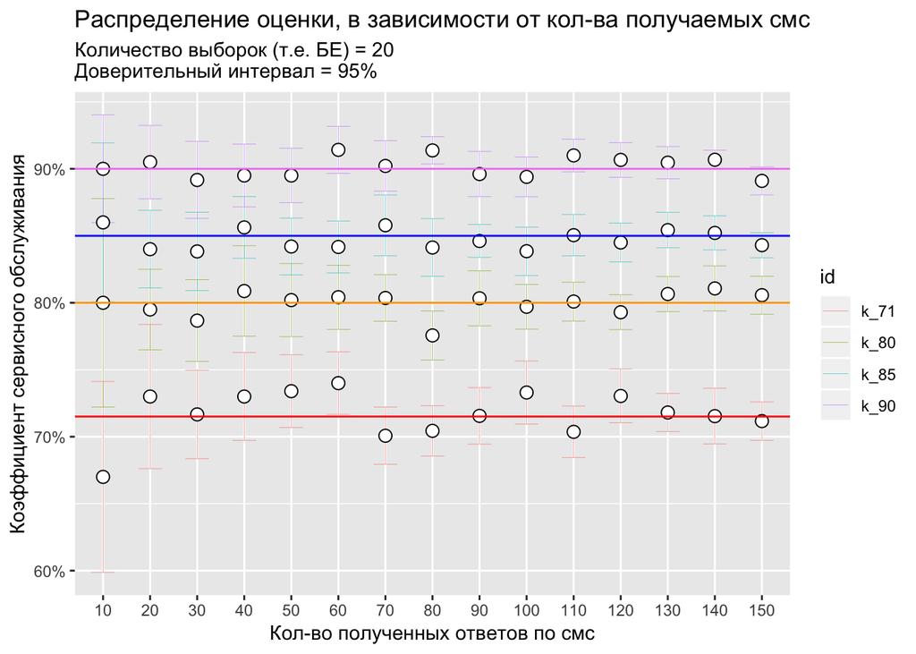

```r
ggplot(total, aes(factor(sms), mean)) +
  geom_errorbar(aes(ymin = ymin, ymax = ymax, color = id), width = 0.5, lwd = 0.1) +
  geom_point(shape = 21, size = 3, fill = 'white') +
  geom_hline(yintercept = 0.900009, color ="violet") +
  geom_hline(yintercept = 0.85, color ="blue") +
  geom_hline(yintercept = 0.80, color ="orange") +
  geom_hline(yintercept = 0.7150774, color ="red") +
  labs(x = "Кол-во полученных ответов по смс",
       y = "Коэффициент сервисного обслуживания",
       title ="Распределение оценки, в зависимости от кол-ва получаемых смс",
       subtitle = "Количество выборок (т.е. БЕ) = 20 \nДоверительный интервал = 95%") +
  scale_y_continuous(labels = function(x) paste0(x*100, "%"))
```

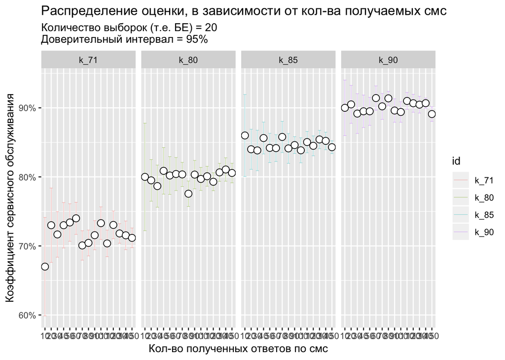

```r
ggplot(total, aes(factor(sms), mean)) +
  geom_errorbar(aes(ymin = ymin, ymax = ymax, color = id), width = 0.5, lwd = 0.1) +
  geom_point(shape = 21, size = 3, fill = 'white') +
  facet_wrap(~id, nrow = 1) +
  labs(x = "Кол-во полученных ответов по смс",
       y = "Коэффициент сервисного обслуживания",
       title ="Распределение оценки, в зависимости от кол-ва получаемых смс",
       subtitle = "Количество выборок (т.е. БЕ) = 20 \nДоверительный интервал = 95%") +
  scale_y_continuous(labels = function(x) paste0(x*100, "%"))
```

На следующем графике наглядно видно, что точность (т.е. величина ошибки) существенно улучшается до количества 70 отправленных смс. А начиная от 70 вплоть до 150 полученных смс оценка улучшается несущественно.

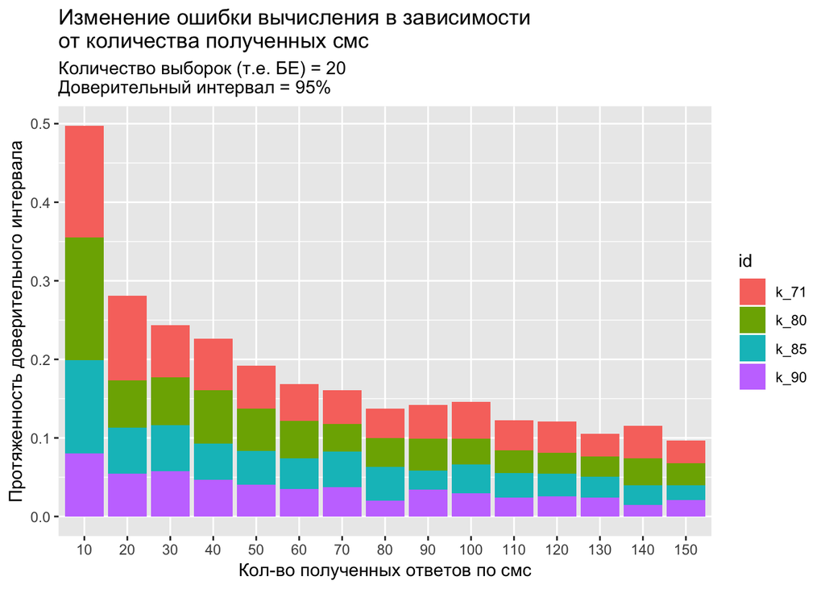

```r
ggplot(total, aes(factor(sms), (ymax-ymin))) +
  geom_col(aes(fill = id)) +
  labs(x = "Кол-во полученных ответов по смс",
       y = "Протяженность доверительного интервала",
       title ="Изменение ошибки вычисления в зависимости\nот количества полученных смс",
       subtitle = "Количество выборок (т.е. БЕ) = 20 \nДоверительный интервал = 95%")
```

**Рекомендуемое количество получаемых смс на одну БЕ в месяц — не менее 70 смс**